# Timeseries Analysis of Political Regimes From 1900 to 2022

# 1 Introduction

- Political regimes are a mean of society to alternate their political leaders. A society has a democratic regime when they can select their leaders through a periodic and contested election with a universal suffrage, while others have an autocratic regime when this method of leaders selection is absent (see Cheibub, et. al 2010 and Boix, et. al 2019).
- The following report examines the distribution of democracies and autocracies from 1900 to 2022 based on the Variety of Democracy (V-Dem) timeseries data (see Coppedge et. al. 2023).
- This report mainly focuses on the annual change in the number of democracies and autocracies across societies with states.
- By states, it means, the population of interest exclusively includes a set of societies who live in a political organization with a centralized coercive power that can enforce a law and order in a specific world’s territory (see Weber 1918).
- Because the states splitted, broke, and absorbed by other states across history (see Przeworski 2013), a state entering or exiting the world historical epoch affects the number of population of regimes in a given time.
- This report follows the coding rule called the Regime in the World to classify political regimes in V-Dem data. This coding rule gives four ordinal categories of regimes based on the presence of periodic contested elections and the deliberation of liberal principles in the said society. This measurement is chosen because it can capture the conceptual essence that have been used in the quantitative and qualitative identifications of political regimes (see more in Lührman et. al 2017).
- Following this coding rule, the classification of political regimes in this report are (i) closed autocracies, (ii) electoral autocracies, (iii) electoral democracies, and (iv) liberal democracies.
- Closed and electoral autocracies are different in the way the latter has an election even it is neither free nor fair while the former does not have this institutional feature at all. Electoral democracies are different from liberal democracies because even though both have a free and fair election, the deliberation of liberal principles, such as protection of minority rights, are not satisfied in electoral democracies as much as in liberal democracies (see more Lührman et. al. 2017).
- To formally express the quantity of interest in this report, let $X_t$ denotes a population of all political regimes in a given time $t$. $X_t$ is a function of four random variables

$$X_t = X_{1t} + X_{2t} + X_{3t} + X_{4t}$$

$X_{1t}, X_{2t}, X_{3t}, X_{4t}$ respectively denote the random variables of closed autocracies, electoral autocracies, electoral democracies, and liberal democracies in a given year $t$. The object of study in this report is the first difference of $X_t$ as defined below.

$$Y_n = \Delta X_t = X_t - X_{t - 1}$$

After taking the first difference of $X_t$, $Y_n$ is a function of the following random variable.

$$Y_n = \Delta X_{1t} + \Delta X_{2t} + \Delta X_{3t} + \Delta X_{4t}$$

Defining $\Delta X_{1t}, \dots, \Delta X_{4t}$ respectively as $Y_{1n}, \dots, Y_{4n}$ gives us

$$Y_n = Y_{1n} + Y_{2n} + Y_{3n} + Y_{4n}$$

$Y_n$ is not constant, because a new state can enter or exit the world state system, drawn from the realization of $Y_{1n} \dots Y_{4n}$ in a given year $n$.

With all these being said, the research questions are the following:

1. Given the realization of $Y_n = y_n$ in the dataset, what time-series model is most favorable?
2. Is there any evidence of cross-correlation between regime change given the realization of $Y_{1n} \dots Y_{4n}$ in data? If so, which regimes have a higher correlation with what other regimes?
3. When a society enters the world history with a creation of new state, what kinds of political regimes they are more likely to be? When the existing sovereign states vanished, what political regimes they are more likely to be?

# 2 Exploratory Data Analysis

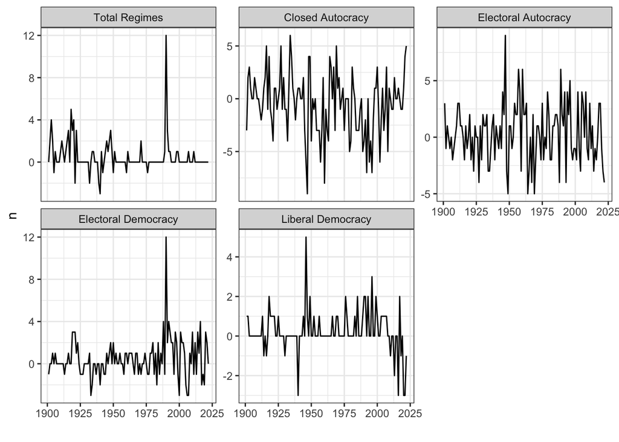

**Figure 1.** Annual Political Regimes Change

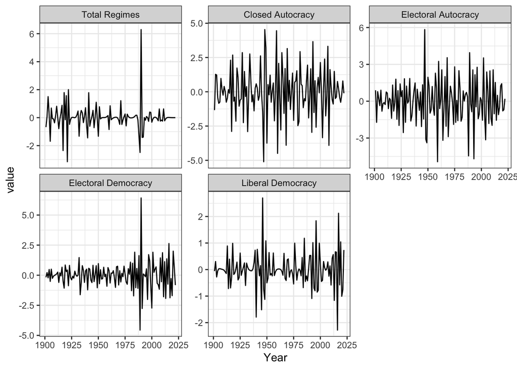

# 3 Frequency Domain Analysis

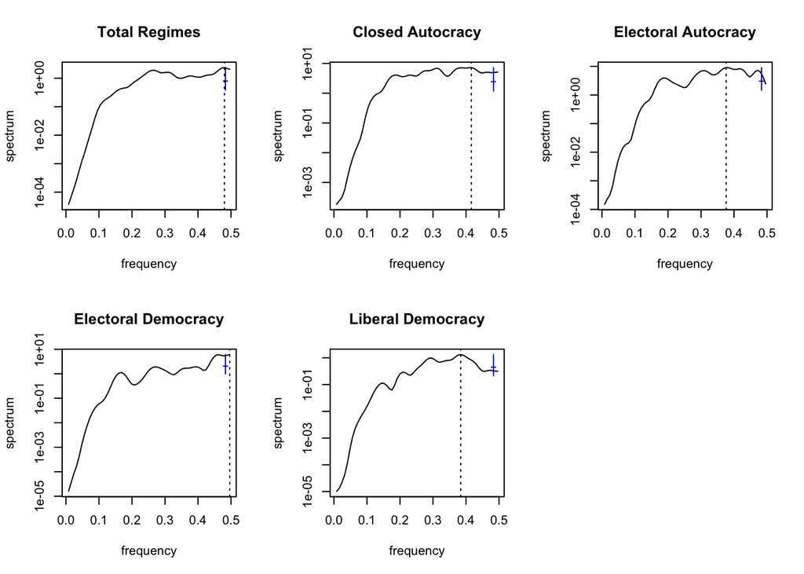

**Figure 3.** The Spectral Density of Detrended Annual Political Regimes Change

**Analysis**:

- The part of this report describes the analysis of the detrended annual regime change in the frequency domain.
- The Figure 3 shows the smoothed periodogram of detrended data with `spans = c(3, 5, 3)` through `spectrum` function for each variable.
- It is noticeable that only the periodograms of detrended `Total Regimes` and `Electoral Democracy` demonstrate an indication of cyclical behavior, because the null hypothesis of no difference, represented in the vertical blue lines, between global maximum, adjascent region, and local minimum is rejected. The periodogram in other variables do not display this behavior.
- The frequency with the highest spectrum in the detrended variables `Total Regimes` and `Electoral Democracy` respectively are $0.48$ and $0.496$. Because the period is defined as $\frac{1}{\text{frequency}}$, it means the periodogram shows an evidence of cyclical behavior of about *two years* in both `Total Regimes` and `Electoral Democracy`.
- Because `Total Regimes` describes the number of sovereign states in the data, this means there has been a period of rise and decline of states within two years period, after removing short-term trends through HP filter. The same pattern can be found in `Electoral Democracy`, where every two years the world has seen states switching regime from and to electoral democracy. Because the variation of regimes are classified in the ordinal scale, this cyclical behavior can also mean a state with `Electoral Autocracy` has implemented a free and fair election, so they switch to `Electoral Democracy` in the regime classification. But it can also mean, a state with a liberal democracy has experienced an eroding liberal values, making their position as `Liberal Democracy` declines as a mere `Electoral Democracy`. It is also possible, a new state emerges and they adopted an `Electoral Democracy` or `Closed Autocracy` implemented a free and fair election reform all of a sudden. The individual spectrum periodogram alone cannot tell which one of these possibilities are more likely.
- To observe the interaction between variables in the frequency domain, a cross-spectrum and coherency periodogram has to be computed. Figure 4 below displays the coherency plot of the pair-wise interaction of observations in the detrended data. The coherency plot is chosen, as opposed to the cross-spectrum periodogram, because it eases the interpretation of correlation.
- The cross-spectrum coherence normalizes the cross-spectrum between detrended variables with the squared of product of each individual spectrum. This makes the interpretation of the behavior between variables in the frequency domain can be accessible immediately.

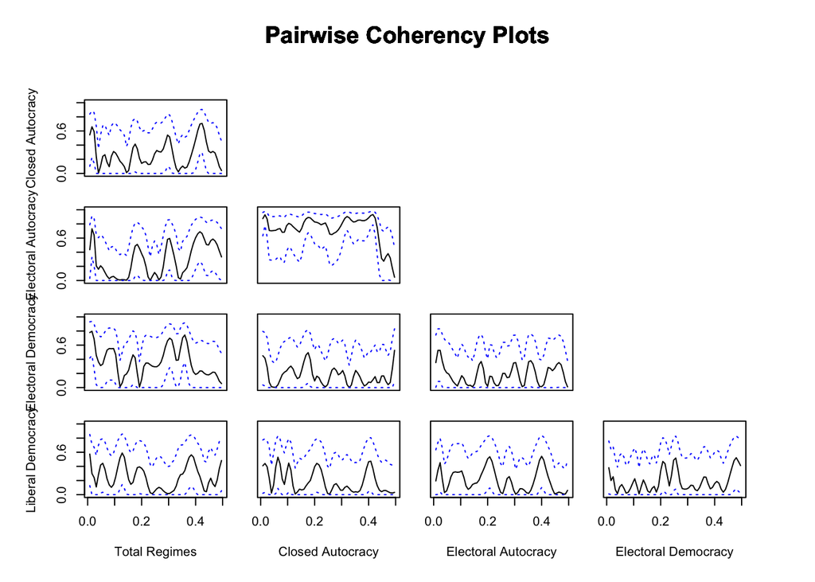

**Figure 4.** The Pair-Wise Squared Coherency Plot

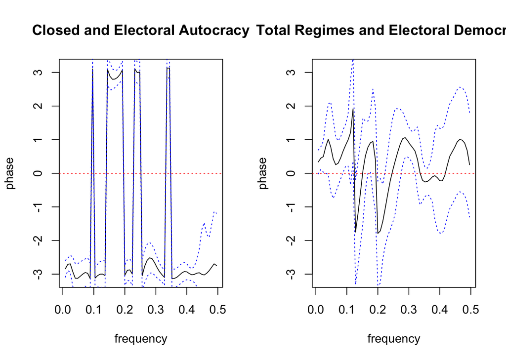

**Figure 5.** The Phase Plot of Selected Variables

# 4 Model Selection

- The following section is focused on selecting the ARIMA model for each variables under investigation.
- The realization of these variables in the dataset shows an indication of a short-term trend before HP filter is applied. Applying HP filter should reduce the short-term trend in each variables, so it extract its cyclical pattern. The ARIMA model fitted below will use this detrended data.
- The null model selected is that each of these random process follows a Gaussian white noise model, as defined below. Let $i = \{0, 1, 2, 3, 4\}$, the null ARIMA model for ordinal regime categories is below.

$$Y_{in} = \mu_i + \epsilon_{in}$$

where $\mu_i$ is the intercept for variable $Y_{in}$ and $\epsilon_in \sim (0, \sigma^2)$.

- The alternative model is selected from the model with the lowest Akaike Information Criterion (AIC) beside the null model. This is computed using Ionedes’ `aic_table` function (see Ionedes 2024). This function generates a table of AIC model given the chosen AR and MA models order in the input. Due to the limitation of space, this table is not shown in this report, but the readers interested can run and display it in the source code.
- To define the area of rejection of hypothesis, the log-likelihood ratio between alternative and null models will be compared with the null distribution under chi-squared with $p - q$ degree of freedom, where $p$ is the number of coefficients in the alternative model and $q$ is the number of coefficients in the null model.
- To prevent the inflation of Type I error in a multiple hypothesis test, the Bonferroni correction is applied to define the adjusted p-value.
- Let $\alpha$ is the desired rejection area and $n$ is the number of test the Bonferroni correction is defined as

$$\text{adjusted critical value} =\frac{\alpha}{n}$$

| Variables | Diff. Log-lik | Alternative Model | Null Hypothesis |
| --- | --- | --- | --- |
| Total Regime | 95.553 | AR(2), MA(3) | Rejected |
| Closed Autocracy | 98.004 | AR(2), MA(4) | Rejected |
| Electoral Autocracy | 108.549 | AR(3), MA(5) | Rejected |
| Electoral Democracy | 112.137 | AR(3), MA(4) | Rejected |
| Liberal Democracy | 111.848 | AR(4), MA(4) | Rejected |

## 4.1 Diagnosis

- The following section analyzes the structure of the model and examines the consistency of its assumptions.
- The first issue to address is to determine if the model is causal and invertible. Determining the causality and invertibility can be done by computing the polynomial roots of respectively AR and MA coefficients. The table below displays the absolute value of polynomial roots of AR and MA coefficients of model for each variables. This table shows that the selected model for each variable is causal and invertible.
- However, the first MA coefficient in `Liberal Democracy` is in the boundary of invertibelity. Computed separatedly, fitting different ARIMA models with adjacent minimum AIC values does not solve this issue and even makes more roots of MA coefficients selected fall within the boundary of unit circle. If the chosen model for `Liberal Democracy` is not invertible but causal, this means there are some features from the data-generating process that is not fully captured, even though forecasting is still acceptable from this model.

| Variables | Model | \|Roots AR\| | \|Roots MA\| |
| --- | --- | --- | --- |
| Total Regime | AR(2), MA(3) | 1.471 1.471 | 1.002 1.002 1.002 |
| Closed Autocracy | AR(2), MA(4) | 1.519 1.519 | 1.002 1.001 1.001 7.499 |
| Electoral Autocracy | AR(3), MA(5) | 1.513 1.123 1.513 | 1.004 1.007 1.002 1.002 7.348 |
| Electoral Democracy | AR(3), MA(4) | 1.361 1.221 1.361 | 1.002 1.002 1.6 1.002 |
| Liberal Democracy | AR(4), MA(4) | 1.276 1.621 1.621 1.276 | 1 1.002 1.002 3.152 |

- The next step of the model diagnosis is to check if there is an indication of heteroscedasticity, serial correlation, and non-normality of the residual.
- To check heteroscedasticity issue, the plots of fitted values against residuals of the model is displayed in the Figure 6.
- Looking at the plots, there is no indication of heteroscedasticity in the data. However, there seems to be an evidence of outlier in the `Total Regimes` and `Electoral Democracy`. After subsetting the observations with the highest residuals in these both variables, it appears the outliers come from the observation with the year index 1989 and 1991 repectively in `Total Regimes` and `Electoral Democracy` variables.
- Recalling the Figure 1 from the previous section, these years refer to the period of the split in the communist states, namely Soviet Union, and the integration of East and West German.

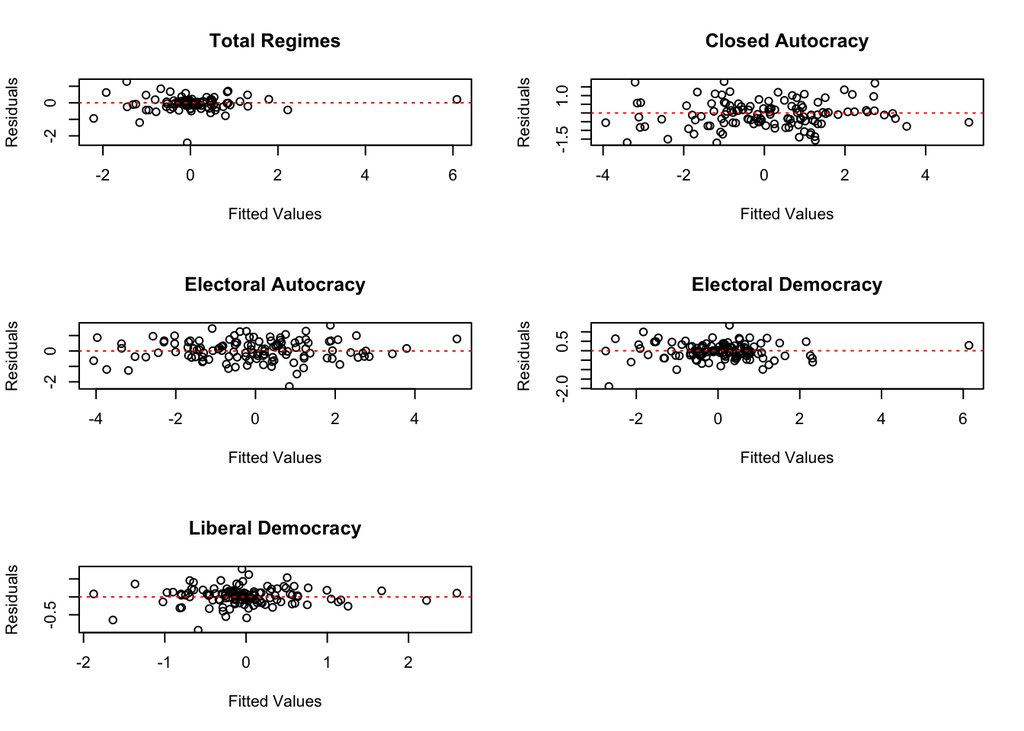

**Figure 6.** The Plot Residuals and Fitted Values

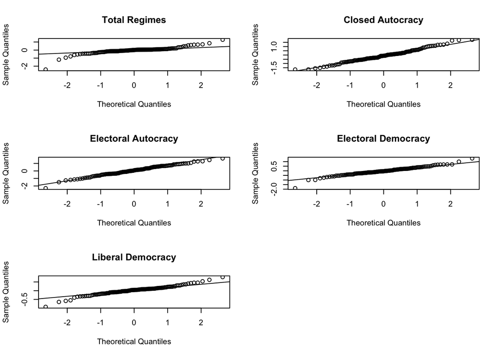

**Figure 7.** The QQ Normal Plot of the Model

- The next issue with the model selection is to examine if there are evidences of serial correlation of residual. This can be done by observing the autocorrelation plots of residuals value in the selected model in each variables, which is displayed in Figure 8.
- The autocorrelation plots in Figure 8 shows there is no indication of serial correlation of residuals in the model fitted in each variables.
- Based on this observation, it seems safe to conclude that the residuals of each of these model are independent and follows the Gaussian normal distribution.

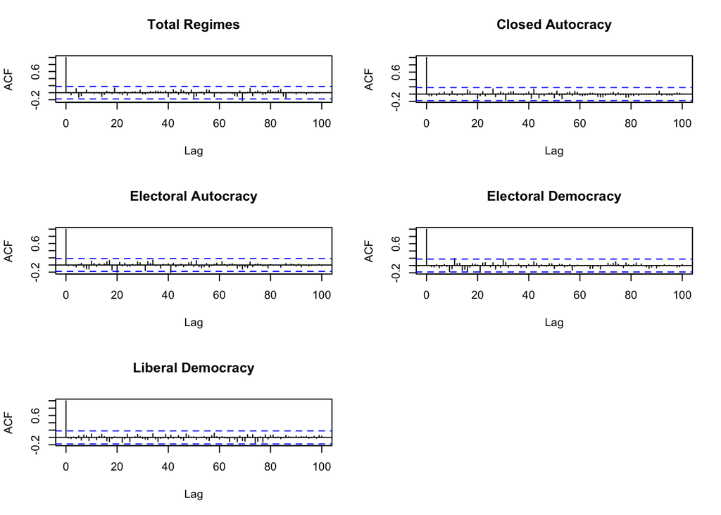

**Figure 8.** The Autocorrelation Plot of the Model’s Residuals

# 5 Model with Trend

- The following section investigates the last research question mentioned in the earlier part of this report: if there is a new sovereign state or the existing sovereign state vanishes, what political regimes they are more likely to be?
- Answering this question involves fitting each selected ARIMA model above with `Total Regimes` as an independent variable.
- The null hypothesis is that there is no relation between the annual change in the total number of regimes, i. e. total number of states, and the annual change of each regime.
- The critical value at $95\%$ is defined by Bonferroni correction, which is $0.0125$.
- Below table shows the result of this hypothesis testing procedure. The second column describes what ARIMA model being used when fitting the model with `Total Regimes` as the independent variable in each variable. The third column describes the difference of log-likelihood value between the alternative and null models.
- This procedure shows the null hypothesis is rejected in the model fitted on `Electoral Democracy` variable. This implies, there is an evidence of association in the annual change in the number of `Electoral Democracy` and the total number of states in the world, as represented in the variable `Total Regimes`.

| Regime | ARIMA Model | Diff. Log-lik | Null Hypothesis |
| --- | --- | --- | --- |
| Closed Autocracy | AR(2), MA(4) | -0.08 | Not Rejected |
| Electoral Autocracy | AR(3), MA(5) | -0.04 | Not Rejected |
| Electoral Democracy | AR(3), MA(4) | 14.26 | Rejected |
| Liberal Democracy | AR(4), MA(4) | 1.53 | Not Rejected |

- The output of the $\texttt{R}$ code below displays the AR(3), MA(4) model of `Electoral Democracy` variable with `Total Regime` as the independent variable. The coefficient of `Total Regime` in this model is called as `diff.total.hpfilter`.
- The positive value of this coefficient indicates a positive association of `Total Regime` and `Electoral Democracy`. Substantively, this means, the number of sovereign states in the world positively increases with the number of electoral democracies. In other words, upon entering the world state system, a society is more likely to adopt electoral democracy as a mean to alternate their political leaders.
- This also means, a decreasing in the annual change of total regime is positively associated with a decreasing number of annual electoral democracies. Substantively, this implies, a vanishing sovereign state is more likely to be an electoral democracy.
- This association, however, does not imply the **causality** of one variable to another.

```
##
## Call:
## arima(x = diff.elect_demo.hpfilter, order = c(3, 0, 4), xreg = diff.total.hpfilter)
##
## Coefficients:
##          ar1     ar2      ar3      ma1     ma2     ma3      ma4  intercept
##       0.1373  0.2185  -0.6061  -2.3325  1.0218  0.9672  -0.6565      0e+00
## s.e.  0.0814  0.0768   0.0818   0.0953  0.2065  0.1923   0.0844      1e-04
##       diff.total.hpfilter
##                    0.5410
## s.e.               0.0878
##
## sigma^2 estimated as 0.1416:  log likelihood = -67.48,  aic = 154.95
```

## 5.1 Diagnosis

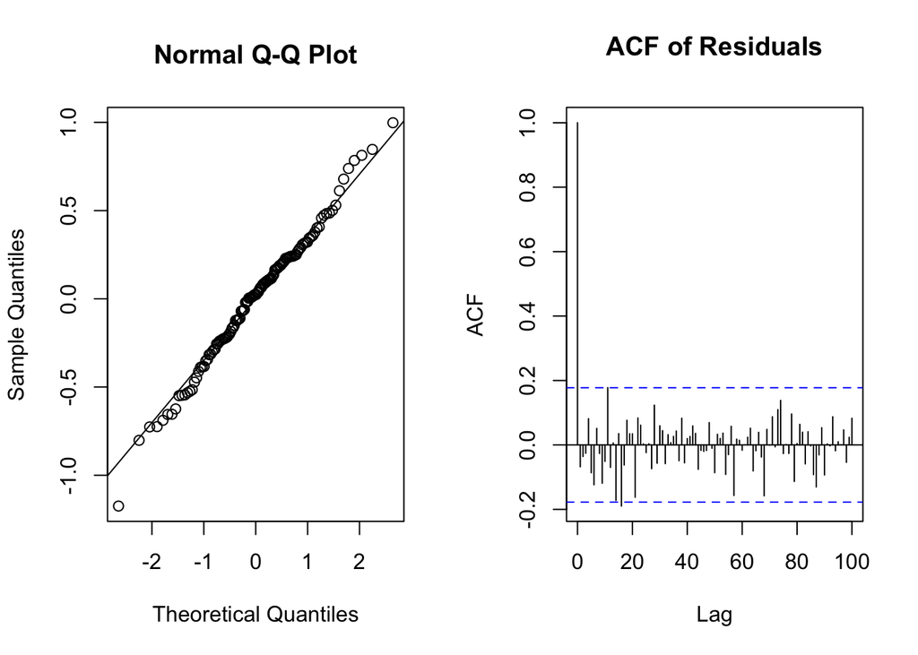

**Figure 9.** The Autocorrelation Plot of the Model’s Residuals

# 6 Conclusion

- This report has demonstrated the time-series analysis of political regimes change since 1900.
- As mentioned in the the exploratory data analysis section, there seems to be a short-term trend in the annual regime change. To extract the cyclical behavior of historical developments of the regime, Hodrick-Prescott (HP) filter is applied in the dataset.
- Analysis presented in this report has answered the three research questions that were mentioned earlier.
- The first question is, given the realization of $Y_n = y_n$ in the dataset, what time-series model is most favorable? The answer to this question is presented in the following table. To recall, each of these models are fitted to the detrended data.

| Variables | Model |
| --- | --- |
| Total Regime | AR(2), MA(3) |
| Closed Autocracy | AR(2), MA(4) |
| Electoral Autocracy | AR(3), MA(5) |
| Electoral Democracy | AR(3), MA(4) |
| Liberal Democracy | AR(4), MA(4) |

$$\phi(B) Y_{in} = \psi(B) \epsilon_{in}$$

where $\phi(B)$ is $p$ order autocorrelaton coefficients and $\psi(B)$ is $p$ order moving average coefficients of selected model for each variables $Y_{1n}$, where $\epsilon_{in} \sim N(0, \sigma^2)$.

- The second question is, is there any evidence of cross-correlation between regime change given the realization of $Y_{1n} \dots Y_{4n}$ in data? If so, which regimes have a higher cross-correlation with what other regimes?
- The answer to this question is addressed in the section on the frequency domain analysis. This analysis has shown that there seems to be a highly matching amplitude between `Closed Autocracy` and `Electoral Autocracy`, as shown in the cross-spectrum coherency plot. This behavior does not manifest in other pairwise coherency plots of eac regime. Above $2.5$ years cycle, the behavior of annual change from these regimes seem to be matched.
- Finally, the last question is, when a new sovereign state enters the world history, what kinds of political regimes they are more likely to be? When the existing sovereign state vanished, what are they more likely to be?
- The last section on Model with Trend answers this question. It shows that, of all regimes, only `Electoral Democracy` has an association with `Total Regimes` at $95\%$ confidence interval with a p-value adjusted with Bonferroni correction.
- Provided that the coefficient of independent variable, `Total Regimes`, are positive, this finding implies if there is a society establishes a new state, `Electoral Democracy` is more likely to be chosen as the mean of political leader selection. In reverse, if a state vanishes from the global politics, they are more likely to be an `Electoral Democracy`.
- The last but not least, as dicussed in the previous section, the future research on regime change can be more insightful by analysing the consequence of long-tailed distribution. The outliers seems to be indicative in all models A future research can be useful to understand the data generating process by examining the systematic origins and consequence of annual regime change.

# 7 References

- Boix, Carles, et. al “A complete data set of political regimes, 1800–2007.” *Comparative political studies* 46, no. 12 (2013): 1523-1554
- Cheibub, José Antonio, Jennifer Gandhi, and James Raymond Vreeland. “Democracy and dictatorship revisited.” *Public choice* 143 (2010): 67-101
- Coppedge, Michael, et. al 2023. “V-Dem Dataset v13” *Varieties of Democracy (V-Dem) Project.* https://doi.org/10.23696/vdemds23.
- Ionedes, Edward. *STATS 531: Lecture Slide 5*. University of Michigan, Ann Arbor: 2024. https://ionides.github.io/531w24/05/slides.pdf
- Lührmann, Anna, et. al “Regimes of the world (RoW): Opening new avenues for the comparative study of political regimes.” *Politics and Governance* 6, no. 1 (2018): 60-77.
- Przeworski, A 2013. *Political Institutions and Political Events (PIPE) Data Set.* https://sites.google.com/a/nyu.edu/adam-przeworski/home/data
- Weber, Max, “Politic as Vocation,” in Gerth, H. H. and C. Wright Mills. *From Max Weber: Essay in Sociology*, New York: Oxford University Press, 1946: 77-128

# 8 Appendix

## 8.1 Appendix I: ACF Plots of Non-Detrended Data

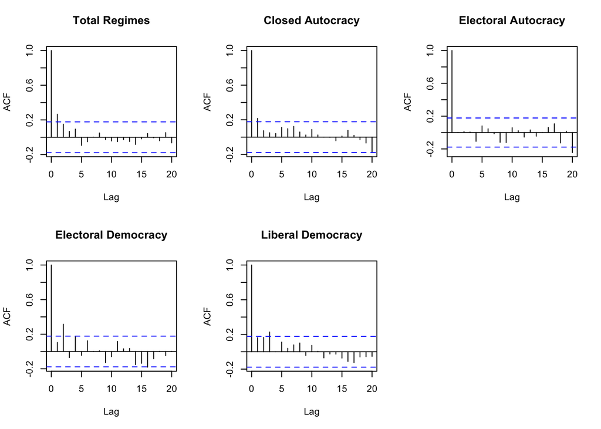